# Hierarhical Models with Binary Latent Variable

Youjin Lee

- Models
- two.1
- two.2
- two.3
- two.4
- summary

## Models

### Notations

- $A_{ij}$ = indicator variable of having edges between node $i$ and node $j$ on graph $G$.($i,j = 1,... , n$)
- $Z_{i}$ = $\{ k ; \mbox{ latent variable of block membership of node } i, k = 1, ... , K \}$
- $X_{i}$ = Node attribute variable.

Recall that what we want to test is independence between $A$ and $X$; since $A$ directly relates to the structure of network (graph) $G$, we assume that we are testing independence between $G$ and $X$.

### Two possible representations

We have suggested two models as data generation schemes.

- [model 1] : $P( A | \color{red}{Z}) P(X | \color{red}{Z} ) P(Z)$
- [model 2] : $P( A | \color{red}{Z}) P(\color{red}{Z} | X) P(X)$

[model 1] implies that a latent variable has an effect on both network structure $A$ and attribute variable $X$; while in [model 2], node attribute $X$ has its influence on $Z$ and $Z$ affects structure $A$.

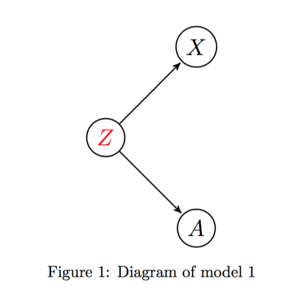

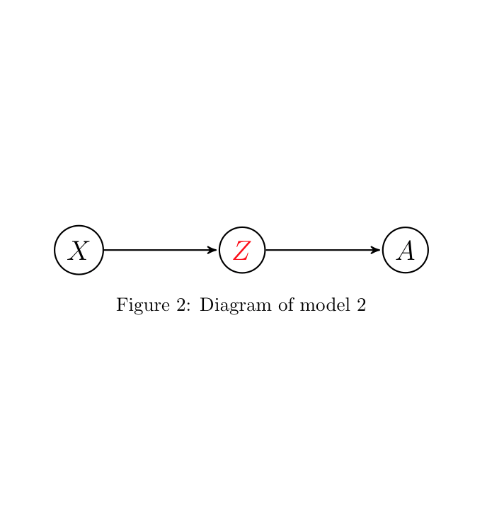

Actually, under the assumption below, two models are exactly equivalent to joint distribution of $(A, Z, X)$.

$\mbox{Assumption 1 : A is independent of X conditional on Z}, i.e. A \perp X \big| Z.$

[Figure 1] and [Figure 2] above illustrates causal diagram of both models. I assume that diagram of [Figure 2] would be more appropriate to schematize the assumption - conditional independence - above. In [Figure 2], a latent variable $Z$ can also be interpreted as an effect modifier or mediator between $X$ and $A$; while in [Figure 1],a latent variable $Z$ acts like a confounder. For both models, $X$ and $A$ are associated with $Z$, and we sometimes adjust for $Z$ to see the effect of $X$ on $A$. If $Z$ is a mediator, it is on the causal pathway from $X$ to $A$, and if $Z$ is an effect modifier, the association/correlation between $X$ and $A$ varies by levels of $Z$; while if $Z$ is a confounder, relationship between $X$ and $A$ is in part or wholly explained by the relationship between $Z$ and $A$. Contextually, even though we are never sure about causal relationship of node attribute and graph(network), we are more interested in explaining association between $X$ and $A$ stratified to $Z$ or fixing $Z$, rather than getting rid of the effect of $Z$ to explain relationship of $X$ and $A$.

- $Lemma$ : Both [Model 1] and [Model 2] are equivalent to joint distribution of $(A, Z, X)$ if $A \perp X \big| Z.$

Proof ) Under the assumption of $A \perp X \big| Z,$

$\begin{align} P(A | Z, X) & = \frac{P(A, Z, X)}{P(Z,X)} \\ & = \frac{P(A, X | Z)P(Z) }{ P(Z,X)} \\ & = \frac{P(A | Z) P(X | Z) P(Z) }{ P(X | Z) P(Z) } \\ & = P(A |Z) \end{align}$

Thus, we can show the equivalence between $P(A | Z) P(X | Z) P(Z)$ and $P(A | Z) P(Z | X) P(X)$, and their equivalence to $P(A, Z, X).$

$\begin{align} P(A | Z) P(X | Z) P(Z) & = P(A | Z) P(X , Z) = P(A | Z) P(Z | X) P(X) \\ & = P(A | Z , X) P(X , Z) \because A \perp X \big| Z \\ & = P(A, Z, X) \end{align} \blacksquare.$

For example, in binary latent case, it suffices to show that $P(X | Z)P(Z) = P(Z | X)P(X).$ Suppose $Z$ and $X | Z$ both follow Bernoulli distributon.

$Z \sim Bern(p)$

$X | Z \sim \left\{ \begin{array}{cc} Bern(q) & Z = 0 \\ Bern(r) & Z = 1 \end{array} \right.$

Then the joint model of $(X,Z)$, marginal distribution of $X$, and conditional distribution of $Z | X$ are the following:

$P(X | Z)P(Z) = \left( q^{x}(1-q)^{1-x} \right)^{1- z} \left( r^{x}(1-r)^{1-x} \right)^{z} p^{z}(1 - p)^{1-z}$

$\begin{align} P(X) & = \sum\limits_{z=0,1}P(X | Z = z)P(Z = z) \\ & = q^{x}(1 - q)^{x} (1-p) + r^{x}(1-r)^{1-x}p \\ & = \left( q (1-p) + rp \right)^{x} \left( (1-q)(1-p) + (1-r)p \right)^{1-x} \end{align}$

$\begin{align} P(Z | X) & = \frac{\left( q^{x}(1-q)^{1-x} \right)^{1- z} \left( r^{x}(1-r)^{1-x} \right)^{z} p^{z}(1 - p)^{1-z}}{\left( q (1-p) + rp \right)^{x} \left( (1-q)(1-p) + (1-r)p \right)^{1-x}} \\ & = \left( \frac{1}{q(1-p) + rp} \big( q(1-p) \big)^{1-z} \big( rp \big)^{z} \right)^{x} \left(\frac{1}{(1-q)(1-p) + (1-r)p} \big( (1-q)(1-p) \big)^{1-z} \big( (1-r)p \big)^{z} \right)^{1-x} \end{align}$

Thus, we can conclude that :

$X \sim Bern(q(1-p) + rp)$

$Z | X \sim \left\{ \begin{array}{cc} Bern(\frac{(1-r)p}{(1-q)(1-p) + (1-r)p } ) & X = 0 \\ Bern(\frac{rp}{q(1-p) + rp}) & X = 1 \end{array} \right.$

For example if $(p,q,r) = (0.5, 0.6, 0.4),$

$Z \sim Bern(0.5)$

$X | Z \sim \left\{ \begin{array}{cc} Bern(0.6) & Z = 0 \\ Bern(0.4) & Z = 1 \end{array} \right.$

is equivalent to

$X \sim Bern(0.5)$

$Z | X \sim \left\{ \begin{array}{cc} Bern(0.6) & X = 0 \\ Bern(0.4) & X = 1 \end{array} \right.$

If $Z$ becomes nuisance, i.e., $X \rightarrow Z \rightarrow A$ is equivalent to $X \rightarrow A$, global test will beat any other local tests.

### Simulation Model

Assume that group (block) membership is a function of $X$, i.e. $Z \sim f(X).$ Suppose that nodes having similar value of $x_{i}$ are more likely to be in the same membership $z_{i}.$

- Generate iid node attribute with a parameter $u$

$X_{i} \overset{i.i.d}{\sim} Bern(u), i = 1,... , n$

- Generate latent variables conditional on $X$ as a function of $\omega$

$Z_{i} | X_{i} \overset{i.i.d}{\sim} Bern(0.5 - \omega (2 X_{i} - 1) ) = \left\{ \begin{array}{cc} Bern(0.5 + \omega) & X_{i} = 0 \\ Bern(0.5 - \omega) & X_{i} = 1 \end{array} \right.$

- Let $Z^{*}_{i} = Z_{i} + 1$ in binary case. Generate local dependent graph of $\phi = (p_{k}, q_{kl}; k,l = 1,...,K, k < l)$ :

$\begin{align} P_{\phi}(A = a | Z^{*} = z^{*}) & = \prod\limits_{k} P_{\phi}(A_{ij} = a_{ij} | Z^{*} = z^{*}) \times \prod\limits_{k < l} P_{\phi} (A_{kl} = a_{kl} | Z^{*} = z^{*}) \\ & = \prod\limits_{Z^{*}_{i} = Z^{*}_{j} = k} {p_{k}}^{a_{ij}}(1-p_{k})^{a_{ij}} \prod\limits_{Z^{*}_{i} =k , Z^{*}_{j} = l} {q_{kl}}^{a_{ij}}(1 - q_{kl})^{a_{ij}} \end{align}$.

Joint likelihood of $(A_{ij}, X_{i}, Z_{i} ; i,j=1,... ,n)$ can be illustrated:

$\begin{align} P_{\theta}(A, X, Z) & = P_{\phi}(A | Z^{*}) P_{\omega}(Z | X) P_{u}(X) \\ & = \prod\limits_{Z^{*}_{i} = Z^{*}_{j} = k; k = 1}^{K} {p_{k}}^{a_{ij}}(1-p_{k})^{a_{ij}} \prod\limits_{Z^{*}_{i} =k, Z^{*}_{j} = l ; k,l = 1, k < l}^{K} {q_{kl}}^{a_{ij}}(1 - q_{kl})^{a_{ij}} \\ & \times \prod\limits_{i=1}^{n} \left[ (0.5 - \omega(2X_{i} - 1))^{z_{i}} \big( 1 - (0.5 - \omega(2X_{i} - 1)) \big)^{1 - z_{i}} u^{x_{i}} (1-u)^{1 - x_{i}} \right] \end{align}$

### [sim] two.1

$K = 2$; $n_{1} = n_{2} = 50$ ; $n = n_{1} + n_{2} = 100.$

| u | w | p1 | p1 | q12 |
| --- | --- | --- | --- | --- |
| 0.5 | 0 | 0.5 | 0.5 | 0.1 |

$\begin{align} P_{\theta}(A, X, Z) & = P_{\phi}(A | Z) P_{\omega}(Z | X) P_{u}(X) \\ & = P_{\phi}( A | Z) P_{\omega}(Z) P_{u} (X) \\ & = \prod\limits_{Z_{i} = Z_{j} = 0}^{1} 0.5^{a_{ij}}(1-0.5)^{a_{ij}} \prod\limits_{Z_{i} \neq Z_{j} } 0.1^{a_{ij}}(1 - 0.1)^{a_{ij}} \prod\limits_{i=1}^{n} (0.5)^{z_{i}} \big( 1 - 0.5) \big)^{1 - z_{i}} \prod\limits_{i=1}^{n} 0.5^{x_{i}} (1-0.5)^{1 - x_{i}} \end{align}$

Since $X \perp Z$ and $X$ is correlated to $A$ only through $Z,$ $X \perp A.$

In this case, it is easy to show that $P(A, X) = P(X) P(A),$ i.e. $X \perp A.$

$\begin{align} P(A, X) & = \sum\limits_{z} P(A, X | Z)P(Z) \\ &= \sum\limits_{z} P(A | Z) p(X | Z) P(Z) (\because A \perp X | Z) \\ & = \sum\limits_{z} P(A | Z )P(Z | X) P(X) \\ & = \sum\limits_{z} P(A | Z)P(Z) P(X) (\because P(Z | X) = P(Z)) \\ & = P(X) \sum\limits_{z} P(A | Z)P(Z) \\ & = P(X)P(A) \end{align}$

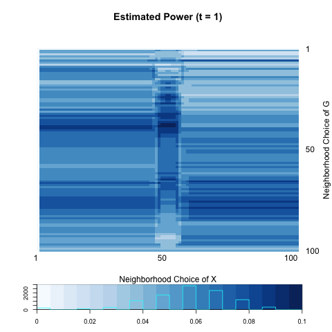

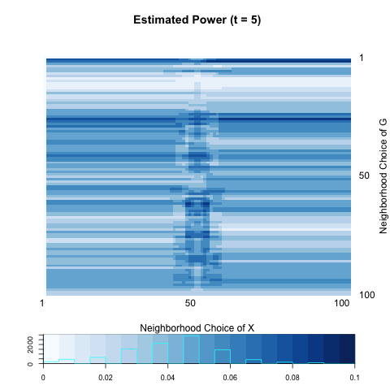

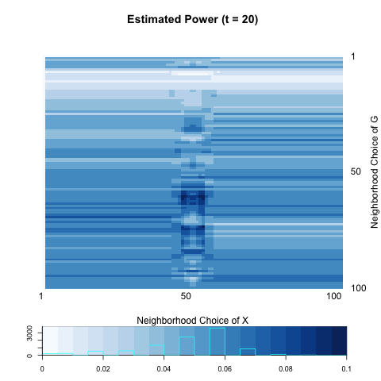

|  | t=1 | t=5 | t=20 |
| --- | --- | --- | --- |
| global test | 0.05 | 0.03 | 0.06 |
| local optimal | 0.10 | 0.09 | 0.10 |

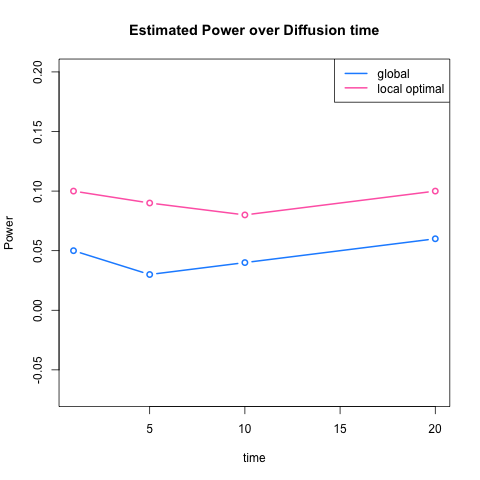

### [sim] two.2

$K = 2$; $n_{1} = n_{2} = 50$ ; $n = n_{1} + n_{2} = 100.$

| u | w | p1 | p2 | q12 |
| --- | --- | --- | --- | --- |
| 0.5 | 0.1 | 0.5 | 0.5 | 0.1 |

$\begin{align} P_{\theta}(A, X, Z) & = P_{\phi}(A | Z) P_{\omega}(Z | X) P_{u}(X) \\ & = \prod\limits_{Z_{i} = Z_{j} = 0}^{1} 0.5^{a_{ij}}(1-0.5)^{a_{ij}} \prod\limits_{Z_{i} \neq Z_{j} } 0.1^{a_{ij}}(1 - 0.1)^{a_{ij}} \\ & \times \prod\limits_{i=1}^{n} \left[ (0.6)^{z_{i}} ( 1 - 0.6)^{1 - z_{i}} I(x_{i} = 0) + (0.4)^{z_{i}} \big( 1 - 0.4 \big)^{1 - z_{i}} I(x_{i} = 1) \right] \prod\limits_{i=1}^{n} 0.5^{x_{i}} (1-0.5)^{1 - x_{i}} \end{align}$

Now $\omega \neq 0,$ so $Z$ has correlation with $X.$

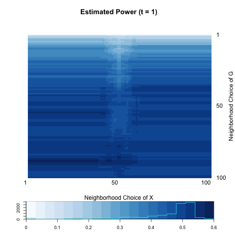

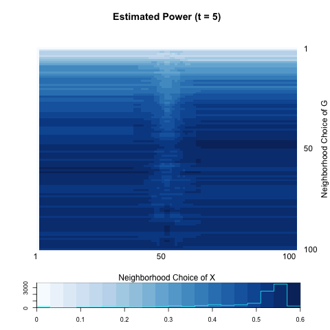

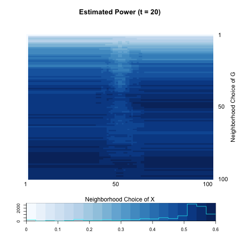

|  | t=1 | t=5 | t=20 |
| --- | --- | --- | --- |
| global test | 0.53 | 0.54 | 0.56 |
| local optimal | 0.58 | 0.59 | 0.60 |

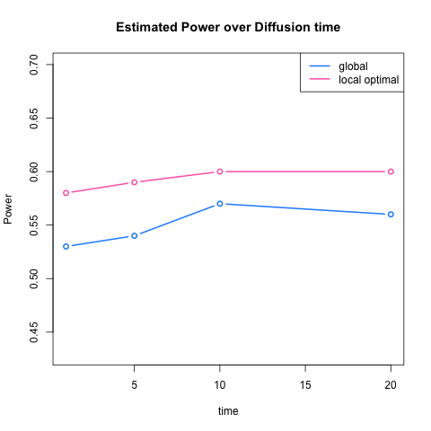

### [sim] two.3

$K = 2$; $n_{1} = n_{2} = 50$ ; $n = n_{1} + n_{2} = 100.$

$\begin{align} P_{\theta}(A, X, Z) & = P_{\phi}(A | Z) P_{\omega}(Z | X) P_{u}(X) \\ & = P_{\phi}(A) P_{\omega}(Z | X) P_{u}(X) \\ & = \prod\limits_{i,j=1}^{n} 0.3^{a_{ij}}(1-0.3)^{a_{ij}} \prod\limits_{i=1}^{n} \left[ (0.6)^{z_{i}} ( 1 - 0.6)^{1 - z_{i}} I(x_{i} = 0) + (0.4)^{z_{i}} \big( 1 - 0.4 \big)^{1 - z_{i}} I(x_{i} = 1) \right] \prod\limits_{i=1}^{n} 0.5^{x_{i}} (1-0.5)^{1 - x_{i}} \end{align}$

Now we set $A \perp Z.$ Since $X$ can be related to $A$ only through $Z,$ $X \perp A.$ You can also show the independence, i.e. $P(A, X) = P(X) P(A)$ through the following equations:

$\begin{align} P(A, X) & = \sum\limits_{z} P(A, X | Z)P(Z) \\ &= \sum\limits_{z} P(A | Z) P(X | Z) P(X) (\because A \perp X | Z) \\ & = \sum\limits_{z} P(A)P(X | Z) P(Z) (\because A \perp Z) \\ & = P(A) \sum\limits_{z} P(X | Z)P(Z) \\ & = P(A) P(X) \end{align}$

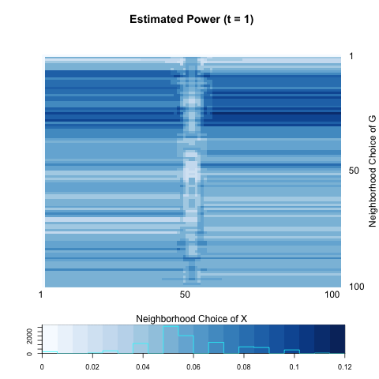

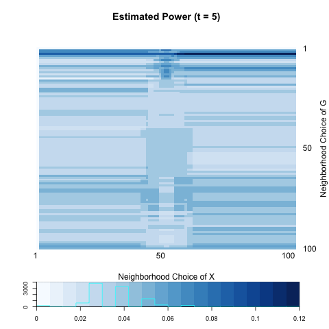

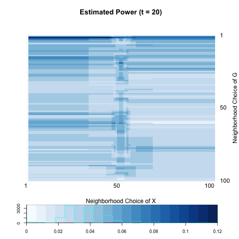

|  | t=1 | t=5 | t=20 |
| --- | --- | --- | --- |
| global test | 0.05 | 0.05 | 0.02 |
| local optimal | 0.11 | 0.12 | 0.12 |

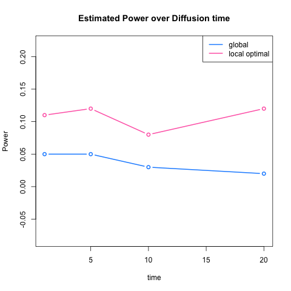

### [sim] two.4

$K = 2$; $n_{1} = n_{2} = 50$ ; $n = n_{1} + n_{2} = 100.$

| u | w | p1 | p2 | q12 |
| --- | --- | --- | --- | --- |
| 0.5 | 0.1 | 0.5 | 0.1 | 0.1 |

$\begin{align} P_{\theta}(A, X, Z) & = P_{\phi}(A | Z) P_{\omega}(Z | X) P_{u}(X) \\ & = \prod\limits_{Z_{i} = Z_{j} = 0} 0.5^{a_{ij}}(1-0.5)^{a_{ij}} \prod\limits_{Z_{i} = Z_{j} = 1} 0.1^{a_{ij}}(1-0.1)^{a_{ij}} \prod\limits_{Z_{i} \neq Z_{j}} 0.1^{a_{ij}}(1 - 0.1)^{a_{ij}} \\ & \times \prod\limits_{i=1}^{n} \left[ (0.6)^{z_{i}} ( 1 - 0.6)^{1 - z_{i}} I(x_{i} = 0) + (0.4)^{z_{i}} \big( 1 - 0.4 \big)^{1 - z_{i}} I(x_{i} = 1) \right] \prod\limits_{i=1}^{n} 0.5^{x_{i}} (1-0.5)^{1 - x_{i}} \end{align}$

Now let $p_{2} = q_{12} < p_{1}$ so that only one block (about 50 $\%$ of tatal sample) has a higher probability.

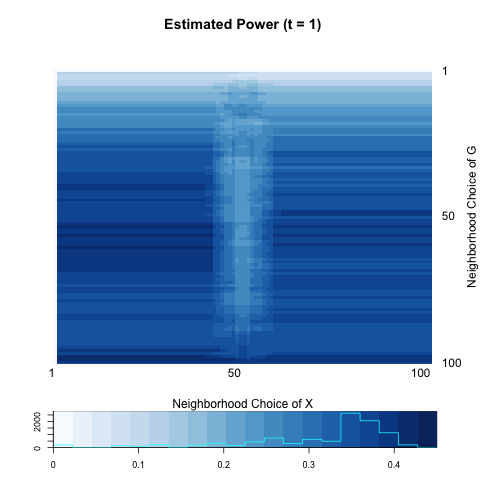

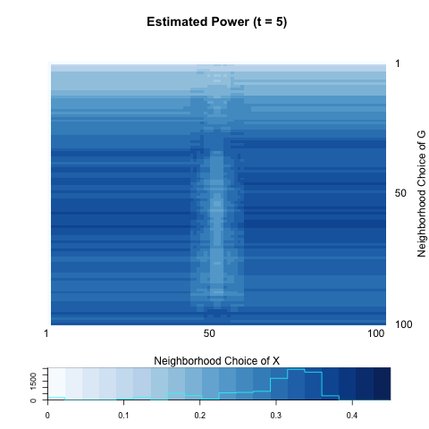

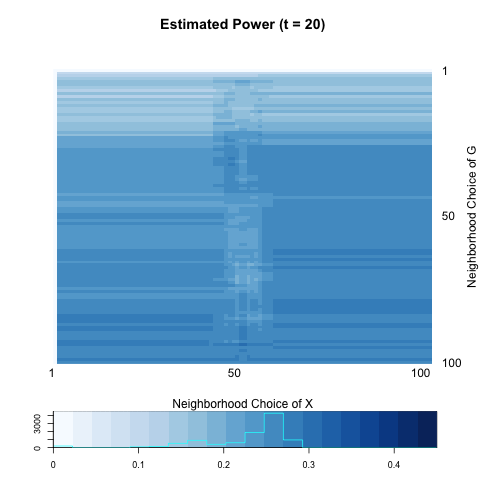

|  | t=1 | t=5 | t=20 |
| --- | --- | --- | --- |
| global test | 0.40 | 0.34 | 0.27 |
| local optimal | 0.42 | 0.38 | 0.30 |

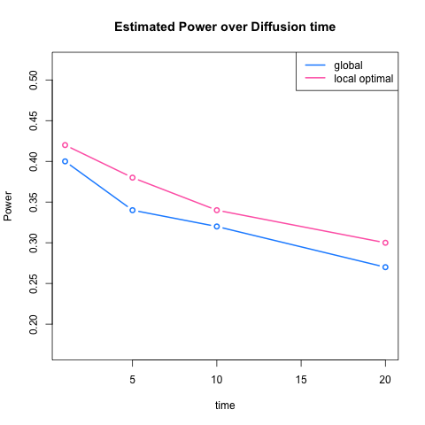

### [sim] two.5

$K = 2$; $n_{1} = n_{2} = 50$ ; $n = n_{1} + n_{2} = 100.$

| u | w | p1 | p2 | q12 |
| --- | --- | --- | --- | --- |
| 0.5 | 0.1 | 0.5 | 0.3 | 0.1 |

$\begin{align} P_{\theta}(A, X, Z) & = P_{\phi}(A | Z) P_{\omega}(Z | X) P_{u}(X) \\ & = \prod\limits_{Z_{i} = Z_{j} = 0} 0.5^{a_{ij}}(1-0.5)^{a_{ij}} \prod\limits_{Z_{i} = Z_{j} = 1} 0.3^{a_{ij}}(1-0.3)^{a_{ij}} \prod\limits_{Z_{i} \neq Z_{j}} 0.1^{a_{ij}}(1 - 0.1)^{a_{ij}} \\ & \times \prod\limits_{i=1}^{n} \left[ (0.6)^{z_{i}} ( 1 - 0.6)^{1 - z_{i}} I(x_{i} = 0) + (0.4)^{z_{i}} \big( 1 - 0.4 \big)^{1 - z_{i}} I(x_{i} = 1) \right] \prod\limits_{i=1}^{n} 0.5^{x_{i}} (1-0.5)^{1 - x_{i}} \end{align}$

Now let $q_{12} < p_{2} < p_{1}$.

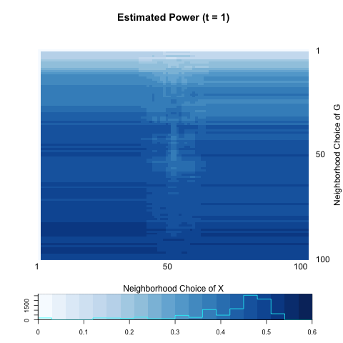

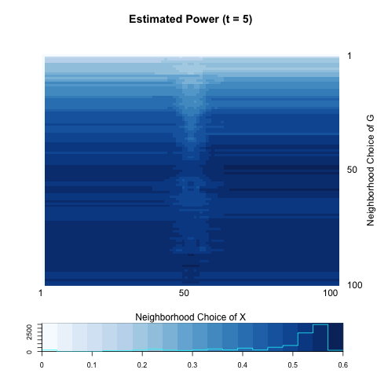

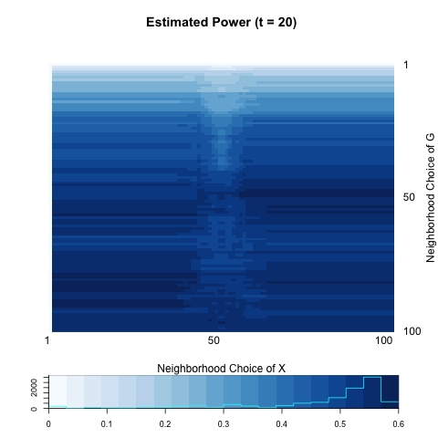

|  | t=1 | t=5 | t=20 |
| --- | --- | --- | --- |
| global test | 0.50 | 0.54 | 0.56 |
| local optimal | 0.54 | 0.58 | 0.60 |

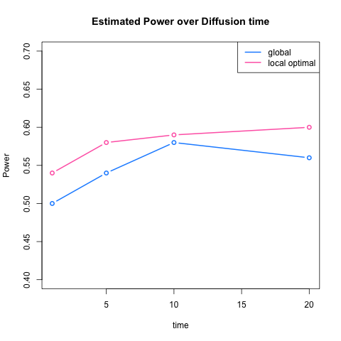

### [sim] two.6

$K = 2$; $n_{1} = n_{2} = 50$ ; $n = n_{1} + n_{2} = 100.$

| u | w | p1 | p2 | q12 |
| --- | --- | --- | --- | --- |
| 0.5 | 0.1 | 0.5 | 0.1 | 0.3 |

$\begin{align} P_{\theta}(A, X, Z) & = P_{\phi}(A | Z) P_{\omega}(Z | X) P_{u}(X) \\ & = \prod\limits_{Z_{i} = Z_{j} = 0} 0.5^{a_{ij}}(1-0.5)^{a_{ij}} \prod\limits_{Z_{i} = Z_{j} = 1} 0.1^{a_{ij}}(1-0.1)^{a_{ij}} \prod\limits_{Z_{i} \neq Z_{j}} 0.3^{a_{ij}}(1 - 0.3)^{a_{ij}} \\ & \times \prod\limits_{i=1}^{n} \left[ (0.6)^{z_{i}} ( 1 - 0.6)^{1 - z_{i}} I(x_{i} = 0) + (0.4)^{z_{i}} \big( 1 - 0.4 \big)^{1 - z_{i}} I(x_{i} = 1) \right] \prod\limits_{i=1}^{n} 0.5^{x_{i}} (1-0.5)^{1 - x_{i}} \end{align}$

Now let $p_{2} < q_{12} < p_{1}$.

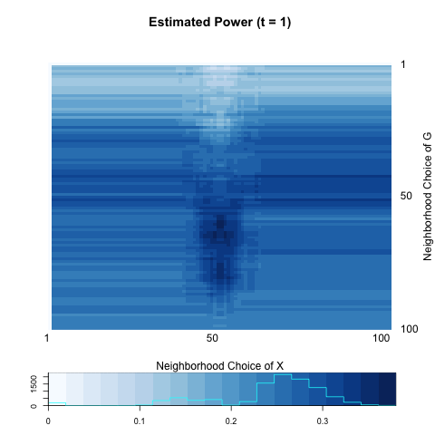

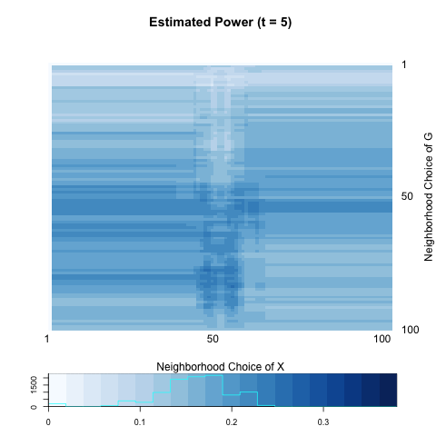

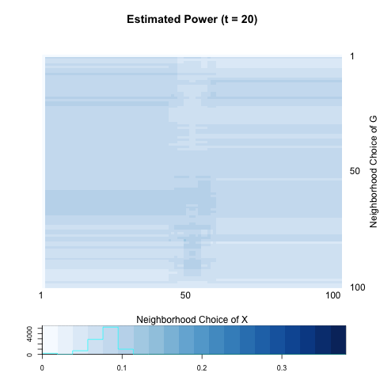

|  | t=1 | t=5 | t=20 |
| --- | --- | --- | --- |
| global test | 0.23 | 0.14 | 0.05 |
| local optimal | 0.37 | 0.25 | 0.12 |

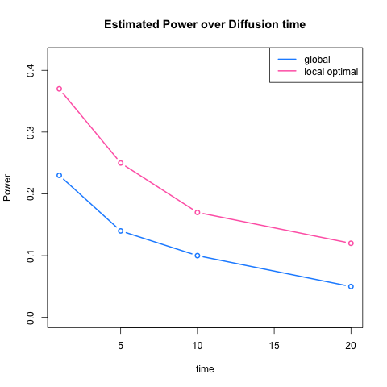

## Summary

Since we now have two types of multiscale - diffusion distance $(t)$, local family $(k,l)$ of test statistics, we summarize the change in optimal power and its change over diffusion process.

### With-block probability p vs. between-block probability q

First, for simplicity, we set the within-block probabilities are homogeneous for two blocks so that we can control two hyper parameters $p$ and $q$:

$X \sim Bern(0.5)$

$Z \sim \left\{ \begin{array}{cc} Bern(0.6) & X = 0 \\ Bern(0.4) & X = 1 \end{array} \right.$

$A \sim Bern \left[ \begin{array}{cc} \color{red}{p} & \color{blue}{q} \\ \color{blue}{q} & \color{red}{p} \end{array} \right]$

### Optimal power

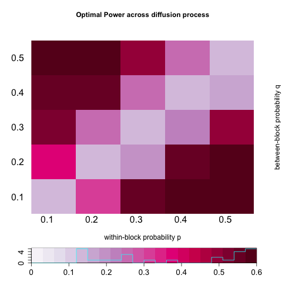

### Discrepancy between local and global scale

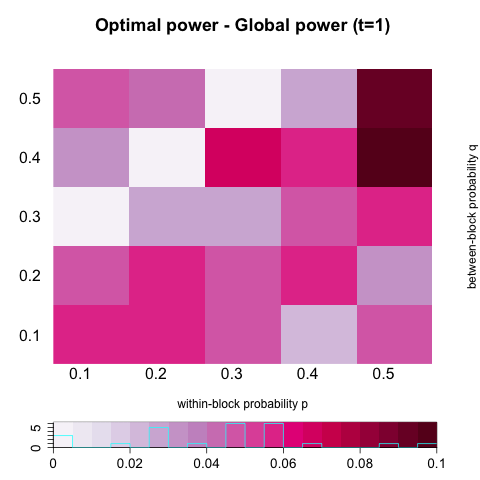

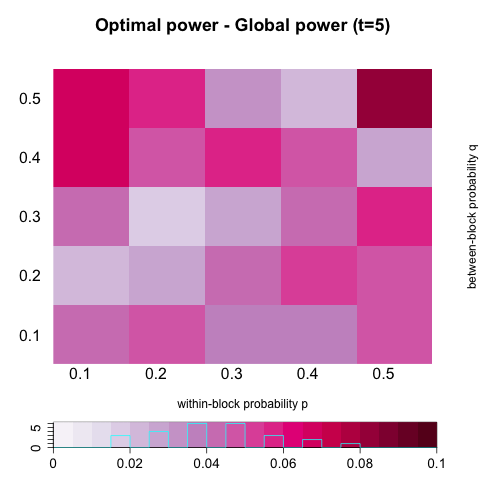

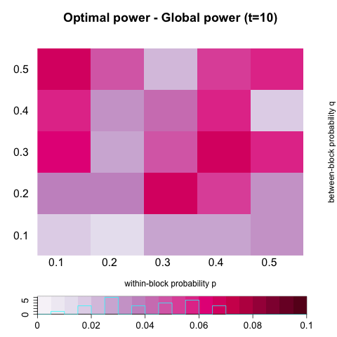

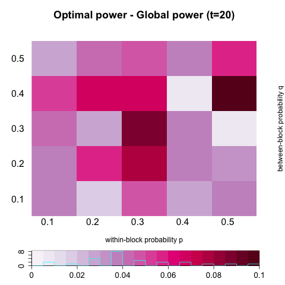